# Seasonal Patterns and Cancellation Analysis in Hotel Booking Data

Azizov Azer

15 noy 2026

**Dataset:** Hotel Booking Demand (Kaggle, jessemostipak), `hotel_bookings.csv`. **Məqsəd:** Pivot cədvəllər və zaman üzrə aqreqasiya ilə otel rezervasiya tələbatını (ay × otel tipi) və ləğv səbəblərini analiz etmək. **Alət:** Analiz R dilində (tidyverse, lubridate, scales, ggplot2) icra olunub.

## Setup və datanın yüklənməsi

```r
# Bütün chunk-lar üçün ümumi parametrlər
knitr::opts_chunk$set(error = FALSE, message = FALSE, warning = FALSE,
                      echo = TRUE, include = TRUE)

library(tidyverse)
library(lubridate)
library(scales)
# agent, company və country sütunlarında boşluqlar "NULL" yazısı kimi saxlanılıb.
# Ona görə na = c("", "NA", "NULL") veririk, agent/company-ni isə rəqəm kimi oxuyuruq.
df <- read_csv("C:/Users/Azer/OneDrive/Desktop/R Devlab/hotel_bookings.csv",
               na = c("", "NA", "NULL"),
               col_types = cols(agent = col_double(),
                                company = col_double(),
                                country = col_character()))

dim(df)  # sətir və sütun sayı
```

```
## [1] 119390     32
```

Dataset 119,390 sətir və 32 sütundan ibarətdir. Boşluqlar `"NULL"` yazısı kimi olduğu üçün onları oxuma zamanı həqiqi `NA`-ya çevirdim.

## Çatışmayan dəyərləri yoxlamaq

```r
# Hər sütunda neçə NA var (yalnız NA olanları göstəririk)
colSums(is.na(df)) %>%
  sort(decreasing = TRUE) %>%
  .[. > 0]
```

```
##  company    agent  country children
##   112593    16340      488        4
```

Çatışmayan dəyərlər dörd sütunda var: `company` (112,593), `agent` (16,340), `country` (488) və `children` (4). `company`-nin təxminən 94%-i boşdur, yəni əksər rezervasiyalarda şirkət göstərilməyib.

## Çatışmayan dəyərləri doldurmaq

```r
df <- df %>%
  mutate(
    country  = replace_na(country, "Unknown"),  # tapşırığa uyğun
    agent    = replace_na(agent, 0),            # tapşırığa uyğun
    company  = replace_na(company, 0),          # tapşırığa uyğun
    children = replace_na(children, 0)          # 4 NA, tapşırıqda yoxdur, 0 ilə dolduruldu
  )

# Yoxlama: NA qalmamalıdır
sum(is.na(df))
```

```
## [1] 0
```

`country` boşluqları “Unknown”, `agent` və `company` boşluqları 0 ilə dolduruldu, `children`-dəki 4 boşluq da 0 oldu. Yoxlamada NA sayı 0-dır, yəni data analizə hazırdır.

## arrival_date sütununu yaratmaq

```r
# Ay adlarının təqvim sırası
month_levels <- c("January", "February", "March", "April", "May", "June",
                  "July", "August", "September", "October", "November", "December")

df <- df %>%
  mutate(
    # Ay adını rəqəmə çeviririk (January -> 1, ..., December -> 12)
    arrival_month_num = match(arrival_date_month, month_levels),

    # İl, ay və günü birləşdirib həqiqi tarix yaradırıq
    arrival_date = make_date(arrival_date_year,
                             arrival_month_num,
                             arrival_date_day_of_month),

    # Ay adını təqvim sırasında factor edirik (pivot və qrafiklər üçün)
    arrival_date_month = factor(arrival_date_month, levels = month_levels)
  )

# Yoxlama
sum(is.na(df$arrival_date))   # 0 olmalıdır
```

```
## [1] 0
```

```r
range(df$arrival_date)        # tarix aralığı
```

```
## [1] "2015-07-01" "2017-08-31"
```

Üç sütun birləşdirilərək `arrival_date` yarandı və heç bir boş tarix qalmadı. Data 2015-07-01 ilə 2017-08-31 arasını əhatə edir.

## Pivot cədvəl (ay × hotel) və heatmap

```r
# Hər ay və hotel üçün rezervasiya sayı
booking_counts <- df %>%
  count(arrival_date_month, hotel)

# Pivot cədvəl: sətir = ay, sütun = hotel, dəyər = rezervasiya sayı
pivot_bookings <- booking_counts %>%
  pivot_wider(names_from = hotel, values_from = n, values_fill = 0) %>%
  arrange(arrival_date_month)

pivot_bookings
```

```
## # A tibble: 12 × 3
##    arrival_date_month `City Hotel` `Resort Hotel`
##    <fct>                     <int>          <int>
##  1 January                    3736           2193
##  2 February                   4965           3103
##  3 March                      6458           3336
##  4 April                      7480           3609
##  5 May                        8232           3559
##  6 June                       7894           3045
##  7 July                       8088           4573
##  8 August                     8983           4894
##  9 September                  7400           3108
## 10 October                    7605           3555
## 11 November                   4357           2437
## 12 December                   4132           2648
```

```r
colSums(pivot_bookings[, c("City Hotel", "Resort Hotel")])  # cəmlər
```

```
##   City Hotel Resort Hotel
##        79330        40060
```

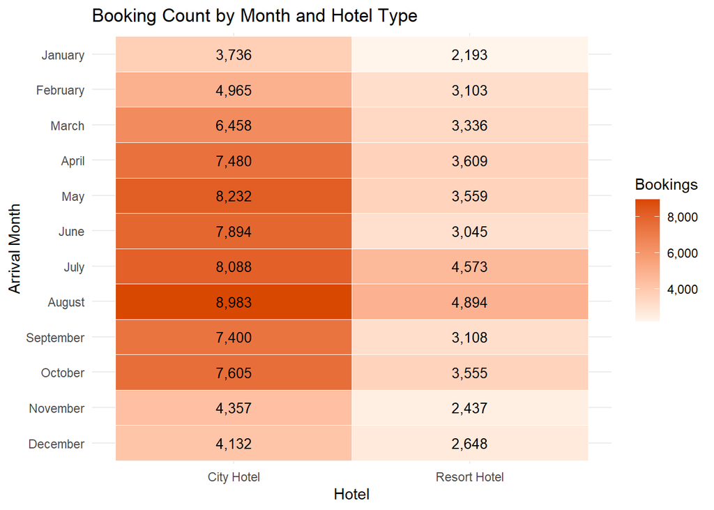

```r
# Heatmap
p_heat <- ggplot(booking_counts, aes(x = hotel, y = arrival_date_month, fill = n)) +
  geom_tile(color = "white") +
  geom_text(aes(label = comma(n)), size = 3.5) +
  scale_y_discrete(limits = rev(month_levels)) +   # Yanvar yuxarıda olsun
  scale_fill_gradient(low = "#fff5eb", high = "#d94801", labels = comma) +
  labs(title = "Booking Count by Month and Hotel Type",
       x = "Hotel", y = "Arrival Month", fill = "Bookings") +
  theme_minimal()

p_heat
```

```r
ggsave("heatmap_month_hotel.png", p_heat, width = 7, height = 6, dpi = 150)
```

City Hotel (79,330) hər ay Resort Hotel-dən (40,060) çox rezervasiya alır, Resort heç bir ayda City-ni üstələmir. Xam saylarda ən yüksək ay Avqustdur (8,983 + 4,894), amma bu nəticə növbəti hissədə il sayına görə dəqiqləşdirilir.

## Normallaşdırma: il sayı fərqini nəzərə almaq

```r
# 1) Hər ay neçə il üzrə data var?
df %>%
  distinct(arrival_date_year, arrival_date_month) %>%
  count(arrival_date_month, name = "n_years") %>%
  arrange(arrival_date_month)
```

```
## # A tibble: 12 × 2
##    arrival_date_month n_years
##    <fct>                <int>
##  1 January                  2
##  2 February                 2
##  3 March                    2
##  4 April                    2
##  5 May                      2
##  6 June                     2
##  7 July                     3
##  8 August                   3
##  9 September                2
## 10 October                  2
## 11 November                 2
## 12 December                 2
```

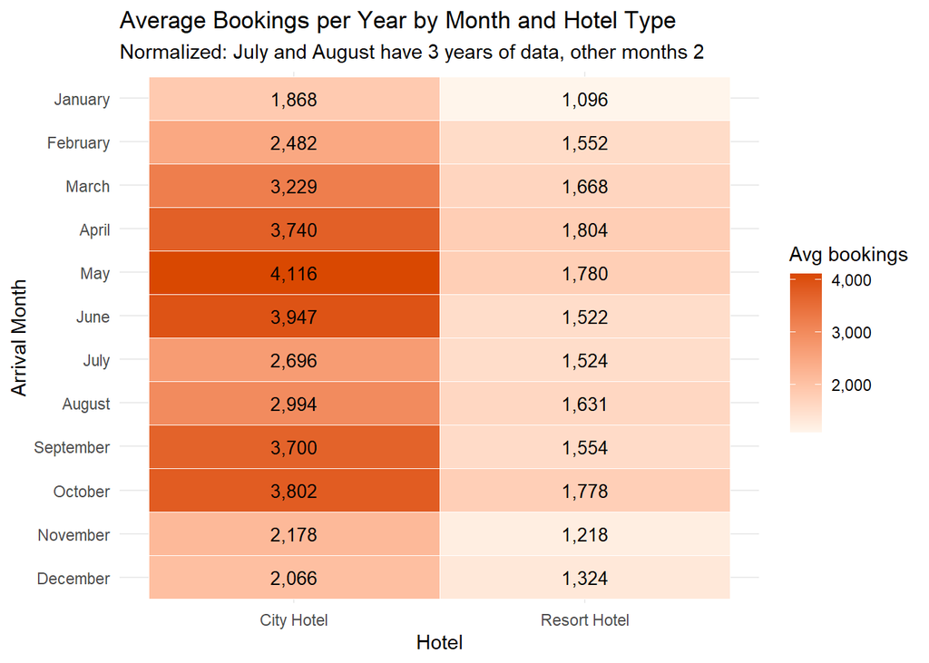

```r
# 2) İl başına orta rezervasiya sayı (ay × hotel)
monthly_avg <- df %>%
  count(arrival_date_year, arrival_date_month, hotel) %>%
  group_by(arrival_date_month, hotel) %>%
  summarise(avg_bookings = round(mean(n)), n_years = n(), .groups = "drop")

# 3) Normallaşdırılmış heatmap
p_heat_avg <- ggplot(monthly_avg, aes(x = hotel, y = arrival_date_month,
                                      fill = avg_bookings)) +
  geom_tile(color = "white") +
  geom_text(aes(label = comma(avg_bookings)), size = 3.5) +
  scale_y_discrete(limits = rev(month_levels)) +
  scale_fill_gradient(low = "#fff5eb", high = "#d94801", labels = comma) +
  labs(title = "Average Bookings per Year by Month and Hotel Type",
       subtitle = "Normalized: July and August have 3 years of data, other months 2",
       x = "Hotel", y = "Arrival Month", fill = "Avg bookings") +
  theme_minimal()

p_heat_avg
```

```r
ggsave("heatmap_month_hotel_normalized.png", p_heat_avg, width = 7, height = 6, dpi = 150)
```

İyul və Avqust datada 3 ildə, digər aylar 2 ildə olduğu üçün xam say bu iki ayı süni şəkildə şişirir. İl başına ortalamada ən yüksək ay May-dır, ən aşağısı Yanvardır; Resort Hotel-də Aprel-Oktyabr arası həcm demək olar sabitdir (təxminən 1,500-1,800).

## Aylıq ləğv nisbəti (hotel üzrə)

```r
# 1) Hotel üzrə ümumi ləğv nisbəti
df %>%
  group_by(hotel) %>%
  summarise(bookings = n(),
            cancel_rate = mean(is_canceled))
```

```
## # A tibble: 2 × 3
##   hotel        bookings cancel_rate
##   <chr>           <int>       <dbl>
## 1 City Hotel      79330       0.417
## 2 Resort Hotel    40060       0.278
```

```r
# 2) Aylıq ləğv nisbəti
cancel_monthly <- df %>%
  group_by(arrival_date_month, hotel) %>%
  summarise(bookings = n(),
            cancelled = sum(is_canceled),
            cancel_rate = mean(is_canceled),
            .groups = "drop")

# Oxumaq üçün geniş cədvəl (faizlə)
cancel_monthly %>%
  select(arrival_date_month, hotel, cancel_rate) %>%
  mutate(cancel_rate = round(cancel_rate * 100, 1)) %>%
  pivot_wider(names_from = hotel, values_from = cancel_rate)
```

```
## # A tibble: 12 × 3
##    arrival_date_month `City Hotel` `Resort Hotel`
##    <fct>                     <dbl>          <dbl>
##  1 January                    39.7           14.8
##  2 February                   38.3           25.6
##  3 March                      36.9           22.9
##  4 April                      46.3           29.3
##  5 May                        44.4           28.8
##  6 June                       44.7           33.1
##  7 July                       40.9           31.4
##  8 August                     40.1           33.4
##  9 September                  42             32.4
## 10 October                    43             27.5
## 11 November                   38.1           18.9
## 12 December                   42.1           23.8
```

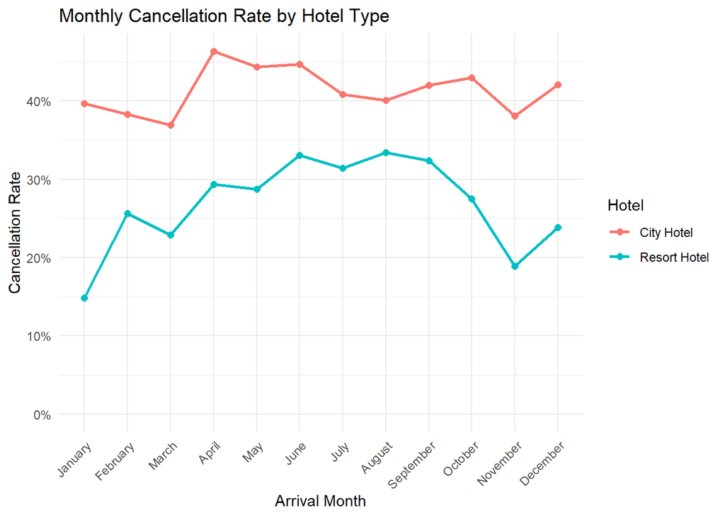

```r
# 3) Xətt qrafiki: iki hotel iki xətt
p_cancel <- ggplot(cancel_monthly,
                   aes(x = arrival_date_month, y = cancel_rate,
                       color = hotel, group = hotel)) +
  geom_line(linewidth = 1) +
  geom_point(size = 2) +
  scale_y_continuous(labels = percent, limits = c(0, NA)) +
  labs(title = "Monthly Cancellation Rate by Hotel Type",
       x = "Arrival Month", y = "Cancellation Rate", color = "Hotel") +
  theme_minimal() +
  theme(axis.text.x = element_text(angle = 45, hjust = 1))

p_cancel
```

```r
ggsave("cancel_rate_monthly.png", p_cancel, width = 8, height = 5, dpi = 150)
```

Ümumi ləğv nisbəti City Hotel-də 41.7%, Resort Hotel-də 27.8%-dir. City il boyu 37-46% aralığında sabitdir, Resort isə mövsümidir: Yanvarda 14.8%, Avqustda 33.4%.

## Lead time: ləğv edilmiş vs edilməmiş

```r
# Ləğv statusuna görə lead_time
df %>%
  group_by(is_canceled) %>%
  summarise(n = n(),
            mean_lead = mean(lead_time),
            median_lead = median(lead_time))
```

```
## # A tibble: 2 × 4
##   is_canceled     n mean_lead median_lead
##         <dbl> <int>     <dbl>       <dbl>
## 1           0 75166      80.0          45
## 2           1 44224     145.          113
```

```r
# Hotel üzrə orta lead_time
df %>%
  group_by(hotel) %>%
  summarise(mean_lead = mean(lead_time))
```

```
## # A tibble: 2 × 2
##   hotel        mean_lead
##   <chr>            <dbl>
## 1 City Hotel       110.
## 2 Resort Hotel      92.7
```

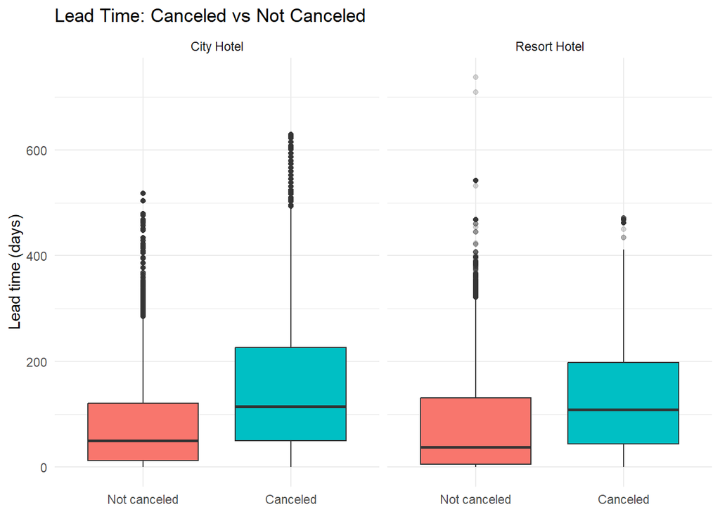

```r
# Boxplot
p_lead <- ggplot(df, aes(x = factor(is_canceled, labels = c("Not canceled", "Canceled")),
                         y = lead_time, fill = factor(is_canceled))) +
  geom_boxplot(show.legend = FALSE, outlier.alpha = 0.2) +
  facet_wrap(~ hotel) +
  labs(title = "Lead Time: Canceled vs Not Canceled",
       x = NULL, y = "Lead time (days)") +
  theme_minimal()

p_lead
```

```r
ggsave("leadtime_boxplot.png", p_lead, width = 8, height = 5, dpi = 150)
```

Ləğv edilən rezervasiyalar orta hesabla 144.8 gün öncədən, edilməyənlər isə 80.0 gün öncədən edilib (median 113 vs 45), yəni fərq ekstremal dəyərlərdən yaranmayıb. Hotel üzrə orta lead_time City-də 109.7, Resort-da 92.7 gündür.

## Top 10 ölkə və ləğv nisbəti

```r
# Ölkələr üzrə rezervasiya sayı və ləğv nisbəti
country_stats <- df %>%
  group_by(country) %>%
  summarise(bookings = n(),
            cancelled = sum(is_canceled),
            cancel_rate = mean(is_canceled),
            .groups = "drop") %>%
  arrange(desc(bookings))

top10 <- country_stats %>% slice_head(n = 10)
top10
```

```
## # A tibble: 10 × 4
##    country bookings cancelled cancel_rate
##    <chr>      <int>     <dbl>       <dbl>
##  1 PRT        48590     27519       0.566
##  2 GBR        12129      2453       0.202
##  3 FRA        10415      1934       0.186
##  4 ESP         8568      2177       0.254
##  5 DEU         7287      1218       0.167
##  6 ITA         3766      1333       0.354
##  7 IRL         3375       832       0.247
##  8 BEL         2342       474       0.202
##  9 BRA         2224       830       0.373
## 10 NLD         2104       387       0.184
```

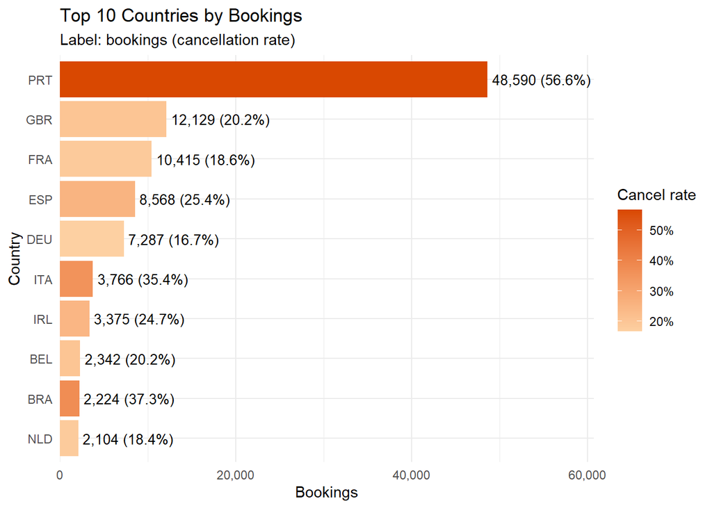

```r
# Bar qrafiki: rəng ləğv nisbətini göstərir
p_country <- ggplot(top10,
                    aes(x = reorder(country, bookings), y = bookings,
                        fill = cancel_rate)) +
  geom_col() +
  geom_text(aes(label = paste0(comma(bookings), " (",
                               round(cancel_rate * 100, 1), "%)")),
            hjust = -0.05, size = 3.5) +
  coord_flip() +
  scale_y_continuous(labels = comma, expand = expansion(mult = c(0, 0.25))) +
  scale_fill_gradient(low = "#fdd0a2", high = "#d94801", labels = percent) +
  labs(title = "Top 10 Countries by Bookings",
       subtitle = "Label: bookings (cancellation rate)",
       x = "Country", y = "Bookings", fill = "Cancel rate") +
  theme_minimal()

p_country
```

```r
ggsave("top10_countries.png", p_country, width = 8, height = 5, dpi = 150)
```

Portekiz (PRT) 48,590 rezervasiya ilə birincidir və ləğv nisbəti 56.6%-dir. Digər top ölkələrdə bu göstərici 16.7% (DEU) ilə 37.3% (BRA) arasındadır, top 10 ölkə isə bütün rezervasiyaların təxminən 84%-ni təşkil edir.

## Market segment analizi

```r
# 1) Segment üzrə tələbat və ləğv
segment_stats <- df %>%
  group_by(market_segment) %>%
  summarise(bookings = n(),
            cancelled = sum(is_canceled),
            cancel_rate = mean(is_canceled),
            .groups = "drop") %>%
  mutate(share = bookings / sum(bookings)) %>%
  arrange(desc(bookings))

segment_stats %>%
  mutate(share = round(share * 100, 1),
         cancel_rate = round(cancel_rate * 100, 1))
```

```
## # A tibble: 8 × 5
##   market_segment bookings cancelled cancel_rate share
##   <chr>             <int>     <dbl>       <dbl> <dbl>
## 1 Online TA         56477     20739        36.7  47.3
## 2 Offline TA/TO     24219      8311        34.3  20.3
## 3 Groups            19811     12097        61.1  16.6
## 4 Direct            12606      1934        15.3  10.6
## 5 Corporate          5295       992        18.7   4.4
## 6 Complementary       743        97        13.1   0.6
## 7 Aviation            237        52        21.9   0.2
## 8 Undefined             2         2       100     0
```

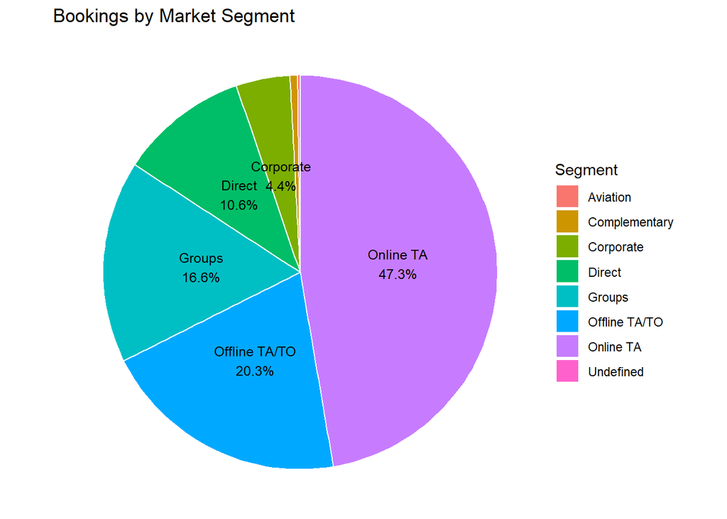

```r
# 2) Pie chart (rezervasiya payı); 2%-dən kiçik dilimlərin yazısı gizlədilir
pie_data <- segment_stats %>%
  mutate(label = ifelse(share >= 0.02,
                        paste0(market_segment, "\n", round(share * 100, 1), "%"),
                        ""))

p_pie <- ggplot(pie_data, aes(x = "", y = bookings, fill = market_segment)) +
  geom_col(width = 1, color = "white") +
  coord_polar(theta = "y") +
  geom_text(aes(label = label),
            position = position_stack(vjust = 0.5), size = 3.3) +
  labs(title = "Bookings by Market Segment", fill = "Segment") +
  theme_void()

p_pie
```

```r
ggsave("market_segment_pie.png", p_pie, width = 7, height = 6, dpi = 150)

# 3) Bonus: ən aşağı ləğv nisbətli segment (100-dən az rezervasiyalı segmentlər çıxarılır)
segment_stats %>%
  filter(bookings >= 100) %>%
  arrange(cancel_rate) %>%
  select(market_segment, bookings, cancel_rate)
```

```
## # A tibble: 7 × 3
##   market_segment bookings cancel_rate
##   <chr>             <int>       <dbl>
## 1 Complementary       743       0.131
## 2 Direct            12606       0.153
## 3 Corporate          5295       0.187
## 4 Aviation            237       0.219
## 5 Offline TA/TO     24219       0.343
## 6 Online TA         56477       0.367
## 7 Groups            19811       0.611
```

Online TA rezervasiyaların 47.3%-ni təşkil edir, ən yüksək ləğv nisbəti isə Groups-dadır (61.1%). Bonus: cəmi 2 sətirlik `Undefined` çıxarılandan sonra ən aşağı ləğv nisbəti Complementary-dədir (13.1%, 743 rezervasiya), böyük həcmli segmentlər arasında isə Direct ən yaxşıdır (15.3%).

## customer_type və deposit_type üzrə yoxlama

```r
# 1) customer_type üzrə pay və ləğv nisbəti
df %>%
  group_by(customer_type) %>%
  summarise(bookings = n(),
            cancel_rate = round(mean(is_canceled) * 100, 1),
            .groups = "drop") %>%
  mutate(share = round(bookings / sum(bookings) * 100, 1)) %>%
  arrange(desc(bookings))
```

```
## # A tibble: 4 × 4
##   customer_type   bookings cancel_rate share
##   <chr>              <int>       <dbl> <dbl>
## 1 Transient          89613        40.7  75.1
## 2 Transient-Party    25124        25.4  21
## 3 Contract            4076        31     3.4
## 4 Group                577        10.2   0.5
```

```r
# 2) deposit_type üzrə pay və ləğv nisbəti
df %>%
  group_by(deposit_type) %>%
  summarise(bookings = n(),
            cancel_rate = round(mean(is_canceled) * 100, 1),
            .groups = "drop") %>%
  mutate(share = round(bookings / sum(bookings) * 100, 1)) %>%
  arrange(desc(bookings))
```

```
## # A tibble: 3 × 4
##   deposit_type bookings cancel_rate share
##   <chr>           <int>       <dbl> <dbl>
## 1 No Deposit     104641        28.4  87.6
## 2 Non Refund      14587        99.4  12.2
## 3 Refundable        162        22.2   0.1
```

```r
# 3) Seçilmiş segmentlər × deposit_type: pay və ləğv nisbəti
df %>%
  filter(market_segment %in% c("Groups", "Online TA", "Direct")) %>%
  group_by(market_segment, deposit_type) %>%
  summarise(bookings = n(),
            cancel_rate = round(mean(is_canceled) * 100, 1),
            .groups = "drop") %>%
  group_by(market_segment) %>%
  mutate(share = round(bookings / sum(bookings) * 100, 1)) %>%
  ungroup()
```

```
## # A tibble: 9 × 5
##   market_segment deposit_type bookings cancel_rate share
##   <chr>          <chr>           <int>       <dbl> <dbl>
## 1 Direct         No Deposit      12581        15.2  99.8
## 2 Direct         Non Refund         19        84.2   0.2
## 3 Direct         Refundable          6        33.3   0
## 4 Groups         No Deposit      10509        28.3  53
## 5 Groups         Non Refund       9172        99.3  46.3
## 6 Groups         Refundable        130        10     0.7
## 7 Online TA      No Deposit      56403        36.6  99.9
## 8 Online TA      Non Refund         56        94.6   0.1
## 9 Online TA      Refundable         18       100     0
```

```r
# 4) PRT vs digər ölkələr × deposit_type: pay və ləğv nisbəti
df %>%
  mutate(is_prt = ifelse(country == "PRT", "PRT", "Other")) %>%
  group_by(is_prt, deposit_type) %>%
  summarise(bookings = n(),
            cancel_rate = round(mean(is_canceled) * 100, 1),
            .groups = "drop") %>%
  group_by(is_prt) %>%
  mutate(share = round(bookings / sum(bookings) * 100, 1)) %>%
  ungroup()
```

```
## # A tibble: 6 × 5
##   is_prt deposit_type bookings cancel_rate share
##   <chr>  <chr>           <int>       <dbl> <dbl>
## 1 Other  No Deposit      70275        23.2  99.3
## 2 Other  Non Refund        411        86.1   0.6
## 3 Other  Refundable        114        11.4   0.2
## 4 PRT    No Deposit      34366        38.9  70.7
## 5 PRT    Non Refund      14176        99.7  29.2
## 6 PRT    Refundable         48        47.9   0.1
```

“Transient” rezervasiyaların 75.1%-ni təşkil edir, bu `customer_type` göstəricisidir (`market_segment` deyil). Non Refund rezervasiyalarının 99.4%-i ləğv olunub, onların 97%-i Portekizdən gəlir və Groups seqmentinin 46.3%-i Non Refund-dur; No Deposit daxilində isə PRT-nin ləğv nisbəti (38.9%) digər ölkələrdən (23.2%) yüksək qalır.

## ADR analizi (bonus): ay × hotel, dual-axis

```r
# adr üçün yoxlama: qeyri-adi dəyərlər
summary(df$adr)
```

```
##    Min. 1st Qu.  Median    Mean 3rd Qu.    Max.
##   -6.38   69.29   94.58  101.83  126.00 5400.00
```

```r
sum(df$adr <= 0)     # sıfır və mənfi qiymətlər
```

```
## [1] 1960
```

```r
sum(df$adr >= 1000)  # ekstremal qiymətlər
```

```
## [1] 1
```

```r
# Aylıq orta adr: yalnız ləğv edilməmiş rezervasiyalar, 0 < adr < 1000
adr_monthly <- df %>%
  filter(is_canceled == 0, adr > 0, adr < 1000) %>%
  group_by(arrival_date_month, hotel) %>%
  summarise(adr = mean(adr), .groups = "drop")

adr_monthly %>%
  mutate(adr = round(adr, 1)) %>%
  pivot_wider(names_from = hotel, values_from = adr)
```

```
## # A tibble: 12 × 3
##    arrival_date_month `City Hotel` `Resort Hotel`
##    <fct>                     <dbl>          <dbl>
##  1 January                    84.4           50.2
##  2 February                   88.3           55.4
##  3 March                      92             58.3
##  4 April                     114.            77.6
##  5 May                       123.            78.5
##  6 June                      120.           110.
##  7 July                      118.           153.
##  8 August                    121.           184.
##  9 September                 116.            97.6
## 10 October                   105.            63.6
## 11 November                   89.2           50.2
## 12 December                   92.3           71.5
```

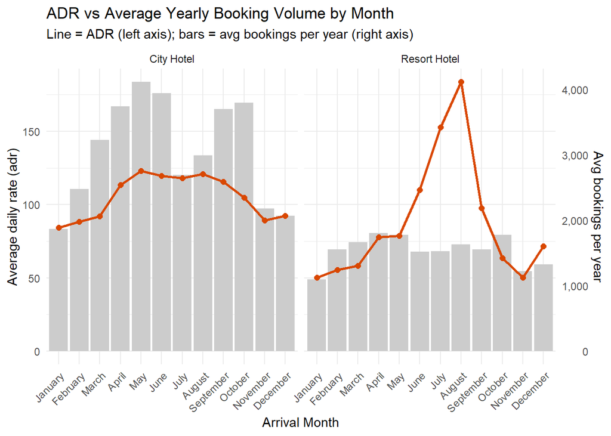

```r
# Dual-axis: xətt = adr (sol ox), bar = il başına orta rezervasiya (sağ ox)
adr_avg <- adr_monthly %>%
  left_join(monthly_avg %>% select(arrival_date_month, hotel, avg_bookings),
            by = c("arrival_date_month", "hotel"))

coef <- max(adr_avg$avg_bookings) / max(adr_avg$adr)

p_adr <- ggplot(adr_avg, aes(x = arrival_date_month)) +
  geom_col(aes(y = avg_bookings / coef), fill = "grey80") +
  geom_line(aes(y = adr, group = 1), color = "#d94801", linewidth = 1) +
  geom_point(aes(y = adr), color = "#d94801", size = 2) +
  scale_y_continuous(name = "Average daily rate (adr)",
                     sec.axis = sec_axis(~ . * coef,
                                         name = "Avg bookings per year",
                                         labels = comma)) +
  facet_wrap(~ hotel) +
  labs(title = "ADR vs Average Yearly Booking Volume by Month",
       subtitle = "Line = ADR (left axis); bars = avg bookings per year (right axis)",
       x = "Arrival Month") +
  theme_minimal() +
  theme(axis.text.x = element_text(angle = 45, hjust = 1))

p_adr
```

```r
ggsave("adr_dual_axis_normalized.png", p_adr, width = 10, height = 5, dpi = 150)
```

Resort Hotel-in ADR-i Yanvardakı 50.2-dən Avqustda 183.7-yə qalxır, halbuki rezervasiya sayı demək olar dəyişmir. City Hotel-in ADR-i 84-123 aralığındadır və May-da zirvəyə çatır. Hesablamada 1,960 sətir (`adr <= 0`) və 1 ekstremal dəyər (5,400) çıxarılıb.

## Revenue management üçün 4 biznes insight

**1. Resort-da mövsümilik həcmdə yox, qiymətdədir.** ADR 50-dən 184-ə qalxır, il başına orta rezervasiya isə Aprel-Oktyabr arası təxminən 1,500-1,800-də qalır. *Tövsiyə:* İyun-Sentyabrda dinamik qiymət tətbiq et, Yanvar və Noyabr-Dekabrda paket və aksiyalarla həcmi artır.

**2. Uzun lead_time ləğv riskini artırır.** Ləğv edilənlər orta hesabla 145 gün, edilməyənlər 80 gün öncədən rezervasiya edilib. *Tövsiyə:* Overbooking buferini lead_time-a və otelə görə təyin et (City-də ləğv 41.7%), 100+ gün öncədən olan rezervasiyalarda yenidən təsdiq və ya qismən ödəniş sına.

**3. Non Refund rezervasiyaları gözlənilməz davranır.** 14,587 rezervasiyanın (12.2%) 99.4%-i ləğv edilib və 97%-i Portekizdəndir; No Deposit daxilində belə PRT-nin ləğv nisbəti 38.9%-dir (digər ölkələrdə 23.2%). *Tövsiyə:* Non Refund-u ləğvdən qoruyucu hesab etmə, onu ayrıca proqnozlaşdır və bu qeydlərin datada necə yazıldığını data sahibi ilə dəqiqləşdir. Bu, hipotezdir, bu analiz səbəbi sübut etmir.

**4. Kanal strukturu.** Direct (15.3%) və Corporate (18.7%) ən etibarlı kanallardır; Online TA həcmin 47.3%-ni verir (ləğv 36.7%). Groups-un 61.1%-lik ləğvi əsasən Non Refund qrup rezervasiyalarından gəlir (No Deposit-də 28.3%). *Tövsiyə:* Direct və Corporate kanalları gücləndir, qrup müqavilə şərtlərini yenidən nəzərdən keçir.

## Məhdudiyyətlər

- Data cəmi 26 ayı əhatə edir; 2015 qismən ildir və City Hotel üçün aşağı həcmlidir.
- Ləğv nisbəti və ADR illər üzrə orta dəyərlərdir, illər arasında qiymət artımını gizlədə bilər.
- Tapıntılar korrelyasiyadır, səbəb-nəticə sübutu deyil.